# Introduction to mitolina: MITOchondrial LINeage Analysis

Mikkel Meyer Andersen

06 June, 2018

## Introduction

First, the library is loaded:

```r
library(mitolina)
```

For reproducibility, the seed for the (pseudo) random number generator is set:

```r
set.seed(1)
```

In this vignette, I will use functionality from the `dplyr` (that loads the pipe operator from the `magrittr` package). More information about these are available at https://magrittr.tidyverse.org/ and http://dplyr.tidyverse.org/.

```r
library(dplyr)
```

## Simulating genealogies

A genealogy is simulated by specifying population sizes for females and males.

```r
sim <- sample_mtdna_geneology_varying_size(
  population_sizes_females = rep(10, 10),
  population_sizes_males = c(0L, rep(10, 9)),
  progress = FALSE)
pop <- sim$population
pop
```

```
## Population with 178 individuals
```

Note, that the first male generation must have size 0.

Please refer to the documentation of `sample_mtdna_geneology_varying_size` (`?sample_mtdna_geneology_varying_size`) for details in variability in reproductive success (VRS) (Andersen and Balding 2017).

This only sample a genealogy. We also need to build pedigrees:

```r
peds <- build_pedigrees(pop, progress = FALSE)
peds
```

```
## List of 8 pedigrees (of size 3, 3, 15, 5, 46, 94, ...)
```

We can then plot one pedigree. We take a pedigree with a male individual in the final generation (`end_generation_male_individuals`):

```r
end_gen_peds <- lapply(sim$end_generation_male_individuals, get_pedigree_from_individual)
pedids <- sapply(end_gen_peds, get_pedigree_id)
id_tab <- sort(table(pedids))
ped_id_endgen <- as.integer(names(id_tab)[1]) # smallest
indv_index <- which(pedids == ped_id_endgen)[1]
ped <- get_pedigree_from_individual(sim$end_generation_male_individuals[[indv_index]])
pedigree_size(ped)
```

```
## [1] 46
```

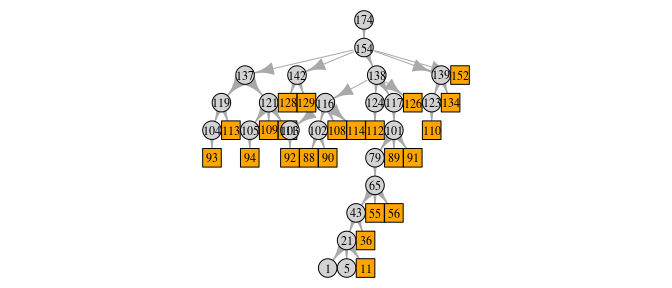

```r
plot(ped)
```

The squares are males and the circles are females.

## Adding mitogenomes

We are now ready to add haplotypes/mitogenomes to the individuals. Let us consider

```r
sites <- 100
```

in the mitogenome for know.

First, we construct a function to create founder haplotypes. Here, they are just random:

```r
get_founder_mito <- function() {
  sample(c(FALSE, TRUE), sites, replace = TRUE)
}
x <- get_founder_mito()
head(x)
```

```
## [1]  TRUE  TRUE  TRUE FALSE FALSE  TRUE
```

```r
sum(x)
```

```
## [1] 51
```

Let us assume the following mutation rates per site:

```r
mu <- rep(1e-2, sites)
```

Now, we can add mitogenomes:

```r
pedigrees_all_populate_haplotypes_custom_founders(
  pedigrees = peds,
  mutation_rates = mu,
  get_founder_haplotype = get_founder_mito,
  progress = FALSE)
```

We can then try to plot the same pedigree again, this time with information about the individuals’ mitogenomes (namely, the number of variants in each individuals mitogenome):

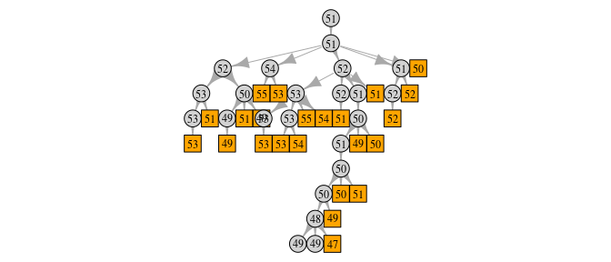

```r
plot(ped, num_vars = TRUE)
```

Plotting with the `igraph` plot quickly becomes difficult to customise. Therefore extensions to the `tidygraph`/`ggraph` packages is provided:

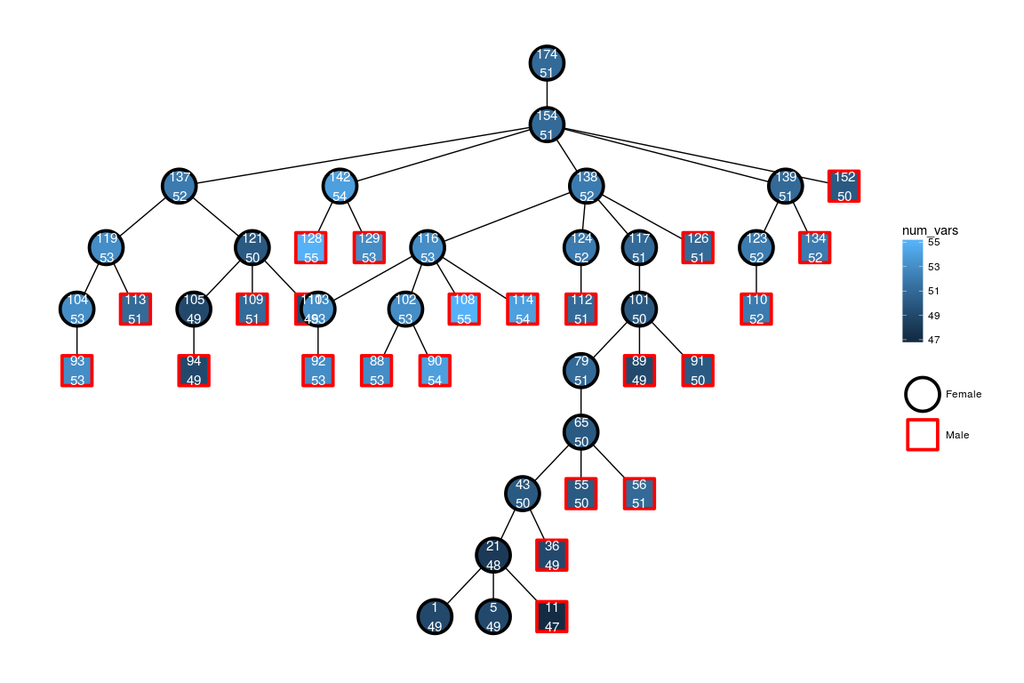

```r
library(tidygraph)
library(ggraph)

g <- as_tbl_graph(peds) %>%
  activate(nodes) %>%
  filter(ped_id == ped_id_endgen) %>%
  mutate(num_vars = sapply(haplotype, sum))

p <- ggraph(g, layout = 'tree') +
  geom_edge_link() +
  geom_node_point(aes(color = sex, fill = num_vars, shape = sex), size = 12, stroke = 2) +
  geom_node_text(aes(label = paste0(name, "\n", num_vars)), size = 4, color = "white") +
  theme_graph(base_family = "") +
  scale_shape_manual(NULL, values = c("Female" = 21, "Male" = 22)) +
  scale_color_manual(NULL, values = c("Female" = "black", "Male" = "red"))
p
```

Here, the top number is the id and the number below is the number of variants in the individual’s mitogenome. Note, how it is possible to get both a (border) color and fill for `pch` values 21-25.

We can also extract all haplotypes in this pedigree:

```r
haps <- get_haplotypes_in_pedigree(ped)
length(haps)
```

```
## [1] 46
```

```r
mean(sapply(haps, sum))
```

```
## [1] 51.28261
```

Or from the last male generation by

```r
haps <- get_haplotypes_individuals(sim$end_generation_male_individuals)
length(haps)
```

[output not shown]

In the simulation function `sample_mtdna_geneology_varying_size`, there is a parameter `generations_return` to decide how many generations are returned in the `male_individuals_generations` and `female_individuals_generations` elements. The default is `3`, meaning that individuals in 3 last generations are returned. So, with the default, the last three generations of males are available in the `male_individuals_generations` element.

```r
haps <- get_haplotypes_individuals(sim$male_individuals_generations)
length(haps)
```

[output not shown]

## mtDNA mutation schemes

There are several datasets with information about the mitogenome included. There is a help file to each of the datasets which can be found by e.g. `?mtdna_partitions` for the `mtdna_partitions` dataset.

First, there is information about the positions from PhyloTree http://www.phylotree.org/resources/rCRS_annotated.htm about the revised Cambridge Reference Sequence (rCRS) (Andrews et al. 1999):

```r
data(mtdna_partitions)
mtdna_partitions %>% print(n = 2)
```

```
## # A tibble: 16,569 x 5
##   Position rCRS  PartitionPhyloTree PartitionRieux PartitionOversti
##      <int> <chr> <chr>              <chr>          <chr>
## 1        1 G     Control_region     HVS1 + HVS2    HVS1 + HVS2
## 2        2 A     Control_region     HVS1 + HVS2    HVS1 + HVS2
## # ... with 1.657e+04 more rows
```

Note, that `PartitionRieux` and `PartitionOversti` have been modified to obtain the same number of positions as were given in the papers (Rieux et al. 2014; Översti et al. 2017).

There is also mutation information from (Rieux et al. 2014)

```r
data(mtdna_mut_Rieux)
mtdna_mut_Rieux
```

```
## # A tibble: 5 x 6
##   PartitionRieux  MutRateYearly   MutHPDLower  MutHPDUpper MutRateSEYearly
##   <chr>                   <dbl>         <dbl>        <dbl>           <dbl>
## 1 PC1 + PC2       0.00000000756 0.00000000571      9.35e-9  0.000000000929
## 2 PC3             0.0000000332  0.0000000257       4.07e-8  0.00000000384
## 3 HVS1 + HVS2     0.000000314   0.000000226        4.03e-7  0.0000000453
## 4 rRNA + tRNA     0.0000000101  0.00000000757      1.27e-8  0.00000000130
## 5 [Not included?] 0             0                  0.       0
## # ... with 1 more variable: MutationScheme <chr>
```

And from (Översti et al. 2017):

```r
data(mtdna_mut_Oversti)
mtdna_mut_Oversti
```

```
## # A tibble: 5 x 6
##   PartitionOversti MutRateYearly  MutHPDLower  MutHPDUpper MutRateSEYearly
##   <chr>                    <dbl>        <dbl>        <dbl>           <dbl>
## 1 PC1 + PC2         0.000000018  0.0000000117 0.000000024    0.00000000314
## 2 PC3               0.0000000304 0.0000000192 0.0000000421   0.00000000584
## 3 HVS1 + HVS2       0.000000206  0.000000125  0.000000290    0.0000000421
## 4 rRNA + tRNA       0.0000000158 0.0000000094 0.0000000230   0.00000000347
## 5 [Not included?]   0            0            0              0
## # ... with 1 more variable: MutationScheme <chr>
```

Note, that `MutRateSEYearly` is found by assuming that the HPD (highest posterior density) is a 95% interval from the Normal distribution.

To use the mutation rates from for example `mtdna_mut_Rieux`:

```r
mu_mean_year <- mtdna_partitions %>%
  left_join(mtdna_mut_Rieux, by = "PartitionRieux") %>% pull(MutRateYearly)
mu_mean_gen <- 25*mu_mean_year
```

Now, `mu_mean_gen` contains a mutation rate per generation (of 25 years) for each of the 16569 sites. The probability of one ore more mutations in a single meiosis is then

```r
1 - prod(1 - mu_mean_gen)
```

```
## [1] 0.01100575
```

Note, that to include variability in the mutation rates, it is probably best to sample a rate per region (in `mtdna_mut_Rieux`), and then distribute that to all sites in the partition:

```r
d_mu_sample <- mtdna_mut_Rieux %>%
  rowwise() %>%
  mutate(mu = 25*rnorm(1, mean = MutRateYearly, sd = MutRateSEYearly))

mu_sample <- mtdna_partitions %>%
  left_join(d_mu_sample, by = "PartitionRieux") %>% pull(mu)
```

We can get an impression of the variability of the overall mutation rate:

```r
get_overall_mu <- function() {
  d_mu_sample <- mtdna_mut_Rieux %>%
    rowwise() %>%
    mutate(mu = 25*rnorm(1, mean = MutRateYearly, sd = MutRateSEYearly))

  mu_sample <- mtdna_partitions %>%
    left_join(d_mu_sample, by = "PartitionRieux") %>% pull(mu)

  1 - prod(1 - mu_sample)
}

set.seed(10)
mu_overall <- replicate(100, get_overall_mu())

summary(mu_overall)
```

```
##     Min.  1st Qu.   Median     Mean  3rd Qu.     Max.
## 0.008937 0.010293 0.010951 0.010940 0.011548 0.013092
```

```r
mean(mu_overall)
```

```
## [1] 0.0109402
```

```r
qnorm(0.975)*sd(mu_overall)
```

```
## [1] 0.001807331
```

```r
quantile(mu_overall, c(0.025, 0.975))
```

```
##        2.5%       97.5%
## 0.009229627 0.012720267
```

These rates are easily used to populate mitogenomes:

```r
get_founder_mito <- function() {
  sample(c(FALSE, TRUE), length(mu_mean_gen), replace = TRUE)
}

pedigrees_all_populate_haplotypes_custom_founders(
  pedigrees = peds,
  mutation_rates = mu_mean_gen,
  get_founder_haplotype = get_founder_mito,
  progress = FALSE)
```

Number of variants in the last three male generations (not just in the one pedigree, but in entire population):

```r
haps <- get_haplotypes_individuals(sim$male_individuals_generations)
table(sapply(haps, sum))
```

```
##
##      0      1
## 250042 247028
```

Number of variants in the last male generation (not just in the one pedigree, but in entire population):

```r
haps <- get_haplotypes_individuals(sim$end_generation_male_individuals)
table(sapply(haps, sum))
```

```
##
##     0     1
## 83298 82392
```

And the same pedigree with new mitogenomes, now where number of variants is a factor to get a discrete fill colour scale:

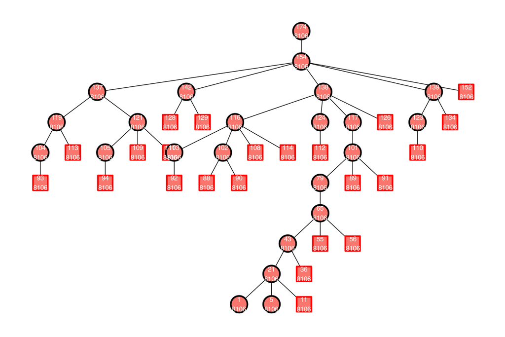

```r
g <- as_tbl_graph(peds) %>%
  activate(nodes) %>%
  filter(ped_id == ped_id_endgen) %>%
  mutate(num_vars = sapply(haplotype, sum))

p <- ggraph(g, layout = 'tree') +
  geom_edge_link() +
  geom_node_point(aes(color = sex, fill = factor(num_vars), shape = sex), size = 12, stroke = 2, show.legend = FALSE) +
  geom_node_text(aes(label = paste0(name, "\n", num_vars)), size = 4, color = "white") +
  theme_graph(base_family = "") +
  scale_shape_manual(NULL, values = c("Female" = 21, "Male" = 22)) +
  scale_color_manual(NULL, values = c("Female" = "black", "Male" = "red"))
p
```

## References

Andersen, MM, and DJ Balding. 2017. “How convincing is a matching Y-chromosome profile?” *PLOS Genetics* 13 (11): e1007028.

Andrews, Richard M, Iwona Kubacka, Patrick F Chinnery, Robert N Lightowlers, Douglass M Turnbull, and Neil Howell. 1999. “Reanalysis and revision of the Cambridge reference sequence for human mitochondrial DNA.” *Nature Genetics* 23.

Översti, Sanni, Päivi Onkamo, Monika Stoljarova, Bruce Budowle, Antti Sajantila, and Jukka U. Palo. 2017. “Identification and analysis of mtDNA genomes attributed to Finns reveal long-stagnant demographic trends obscured in the total diversity.” *Scientific Reports* 7.

Rieux, Adrien, Anders Eriksson, Mingkun Li, Benjamin Sobkowiak, Lucy A. Weinert, Vera Warmuth, Andres Ruiz-Linares, Andrea Manica, and François Balloux. 2014. “Improved Calibration of the Human Mitochondrial Clock Using Ancient Genomes.” *Molecular Biology and Evolution* 31 (10): 2780–92.